# Data Camp / Forecasting Using R - Chapter 3

Initialize and load the data

```r
library(ggplot2)
library(forecast)
library(fpp)
```

Chapter 3 of [Data Camp - Forecasting Using R](https://www.datacamp.com/courses/forecasting-using-r)

## Exponential Forecast

### Simple Exponential smoothing

In R uses the `ses()` function. The parameters (noted below) are estimated using least squares estimation.

**Forecasting Notation:**

$\hat{y}_{t+h|t}=$ point forecast of $y_{t+h}$ given data $y_1, ..., y_t$

**Forecast Equation:**

$\hat{y}_{t+h|t} = \alpha y_t + \alpha(1 - \alpha) y_{t-1} + \alpha(1 - \alpha)^2 y_{t-2} + ...$ Where $0 \leq \alpha \leq 1$

This can be (more conveniently) represented as:

Forecast equation: $\hat{y}_{t+h|t} = \ell_t$

Smoothing equation: $\ell_t = \alpha y_t + (1-\alpha)\ell_{t-1}$

- $\ell_t$ is the **level** (smoothed value) of the series at time t.

The forecast is the most recent estimate of the $\ell$ **(level)**.

$\ell$ *evolves* over time based on the most recent observation and the previous estimate of the level.

There are 2 components to estimate $\alpha$, initial value of $\ell_0$

This is all handled in R by the `ses()` function.

```r
data(oil)
oildata = window(oil, start=1996)
fc = ses(oildata, h=5)
summary(fc)
```

```
##
## Forecast method: Simple exponential smoothing
##
## Model Information:
## Simple exponential smoothing
##
## Call:
##  ses(y = oildata, h = 5)
##
##   Smoothing parameters:
##     alpha = 0.7864
##
##   Initial states:
##     l = 448.1323
##
##   sigma:  26.0411
##
##      AIC     AICc      BIC
## 144.4110 146.5928 146.5352
##
## Error measures:
##                    ME    RMSE      MAE       MPE     MAPE      MASE
## Training set 1.791802 26.0411 20.80437 0.2055117 4.391835 0.9293995
##                     ACF1
## Training set -0.01073866
##
## Forecasts:
##      Point Forecast    Lo 80    Hi 80    Lo 95    Hi 95
## 2011       469.2678 435.8948 502.6409 418.2282 520.3075
## 2012       469.2678 426.8120 511.7237 404.3372 534.1984
## 2013       469.2678 419.3555 519.1802 392.9335 545.6021
## 2014       469.2678 412.8765 525.6592 383.0248 555.5109
## 2015       469.2678 407.0688 531.4669 374.1426 564.3931
```

What does the above tell us?

alpha tells us that 79% of the forecasting is done on the first observation, then

((1 - .79) * .79)% on the second and the remaining on the remaining points. $\ell_0$ is 448.1323.

h was set to 5 to take us out the next 5 years. This forecast is stored in the fc object.

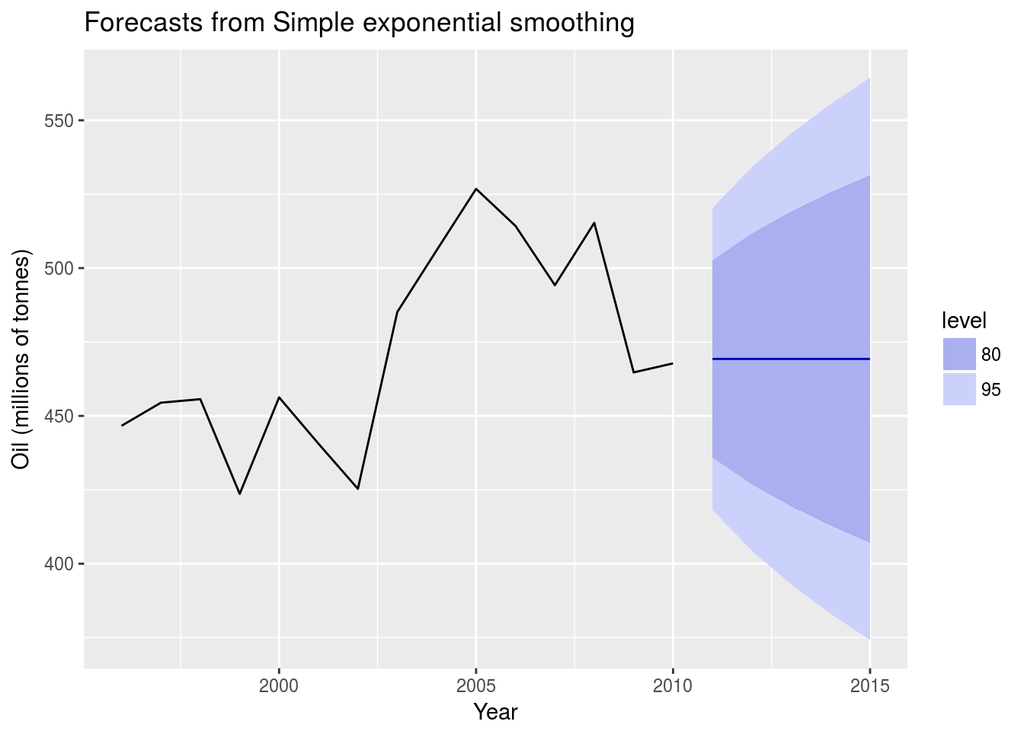

```r
autoplot(fc) +
  ylab("Oil (millions of tonnes)") +
  xlab("Year")
```

## Holt’s linear trend

You need to add to the simple exponential smoothing a component for trending. This leaves us with the following equasions:

Forecast equation: $\hat{y}_{t+h|t} = \ell_t + hb_t$

Level (Smoothing equation): $\ell_t = \alpha y_t + (1-\alpha)(\ell_{t-1} + b_{t-1})$

Trend : $b_t = \beta^*(\ell_t - \ell_{t-1}) + (1 - \beta^*)b_{t-1}$

Because the slope can change this is often called a “Local Linear Trend”

Smaller $\beta^*$ means slower slope changes.  
Larger $\beta^*$ means faster slope changes.

There are now **4** parameters

- 2 for smoothing $\alpha$ and $\beta^* (0 \leq \alpha,\beta^* \leq 1)$
- 2 state parameters $\ell_0$ and $b_0$
- Choose $\alpha, \beta^*, \ell_0, b_0 to minimize SSE$

The **Holt** method will have a constant slope over time.

The `holt()` function handles the minimizing of parameters.

Here is an example of forecasting with Holt’s method in R, forecasting for 5 years forward, using data from 1990 - 2004.

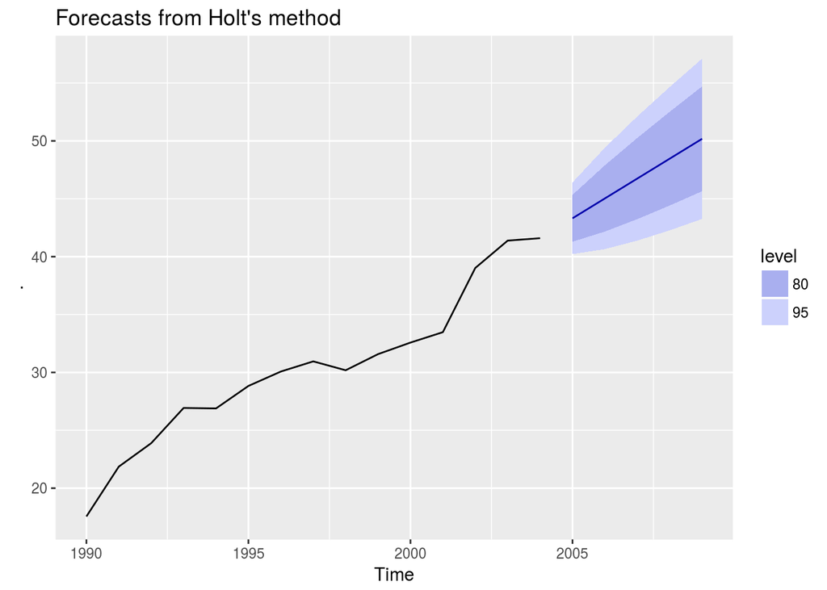

```r
ausair %>%
  window(start=1990, end=2004) %>%
  holt(h=5) %>%
  autoplot
```

## Damped trend method

The Dampled trend method will allow the slope to dampen over time. The equasions for this are:

$\hat{y}_{t+h|t} = \ell_t + (\phi + \phi^2 + ... + \phi^h)b_t$  
$\ell_t = \alpha y_t + (1 - \alpha)(\ell_{t-1} + \phi b_{t-1})$ $b_t = \beta^*(\ell_t - \ell_{t-1}) + (1-\beta^*)\phi b_{t-1}$

This is basically Holt’s method with 1 extra parameter $\phi$ as a dampening parameter where $0 \leq \phi \leq 1$. Where if $\phi = 1$ you have a linear trend identical to Holt’s.

With this, the **short-run forecasts** are *trended* but the **long-run forecasts** are *constant*.

**NOTE**: The **PI** parameter controls the upper/lower control bounds plotting. When FALSE, it’s not displayed, when TRUE it is. This is not documented in the help for `holt()`.

To add **dampening** add the **damped=TRUE** option to the `holt()` function call.

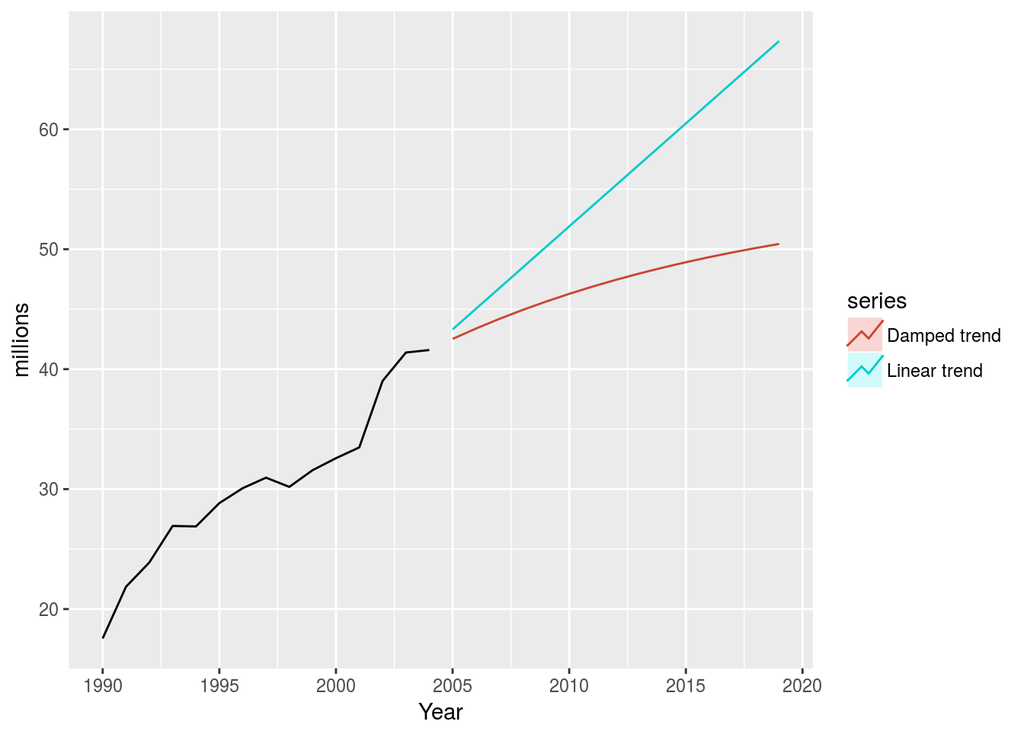

```r
window(ausair, start=1990, end=2004) -> airpassengers

holt(airpassengers, h=15, PI=FALSE) -> fc1
holt(airpassengers, h=15, PI=FALSE, damped=TRUE) -> fc2

autoplot(airpassengers) +
  xlab("Year") +
  ylab("millions") +
  autolayer(fc1, series="Linear trend") +
  autolayer(fc2, series="Damped trend")
```

Below looks at visitors to austraila.

Using the Holt function to forecast 10 years out.

Note the checkrisudals has a high p-value so the residuals are not well correlated. That’s good!  
The ACF chart shows all values are insignficant, the residuals “look like” white noise and are relatively normally distributed so these all point to a “good” model. Or, at least a model that isn’t missing any information.

```r
holt(austa, h=10) -> fc
summary(fc)
```

```
##
## Forecast method: Holt's method
##
## Model Information:
## Holt's method
##
## Call:
##  holt(y = austa, h = 10)
##
##   Smoothing parameters:
##     alpha = 0.9923
##     beta  = 1e-04
##
##   Initial states:
##     l = 0.6697
##     b = 0.1537
##
##   sigma:  0.1744
##
##       AIC      AICc       BIC
##  8.162957 10.562957 15.332893
##
## Error measures:
##                        ME      RMSE      MAE       MPE     MAPE      MASE
## Training set 0.0001786754 0.1743617 0.151103 -1.042043 6.204044 0.8041347
##                   ACF1
## Training set 0.1819316
##
## Forecasts:
##      Point Forecast    Lo 80    Hi 80    Lo 95    Hi 95
## 2011       5.593741 5.370288 5.817195 5.251998 5.935484
## 2012       5.747443 5.432612 6.062274 5.265951 6.228936
## 2013       5.901146 5.516028 6.286263 5.312159 6.490132
## 2014       6.054848 5.610413 6.499283 5.375144 6.734553
## 2015       6.208550 5.711822 6.705279 5.448870 6.968231
## 2016       6.362253 5.818225 6.906280 5.530234 7.194271
## 2017       6.515955 5.928416 7.103494 5.617391 7.414519
## 2018       6.669657 6.041606 7.297709 5.709135 7.630180
## 2019       6.823360 6.157247 7.489472 5.804629 7.842091
## 2020       6.977062 6.274942 7.679182 5.903263 8.050861
```

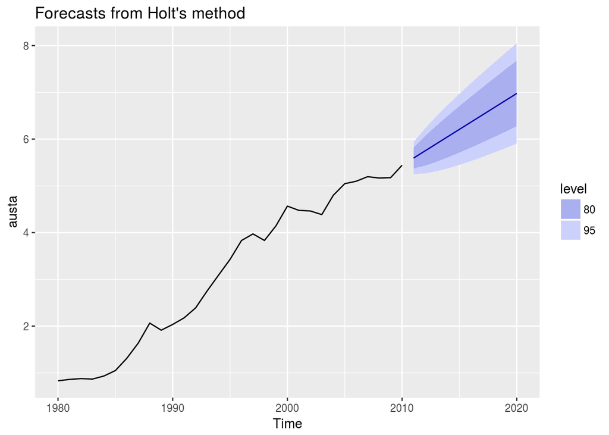

```r
autoplot(fc)
```

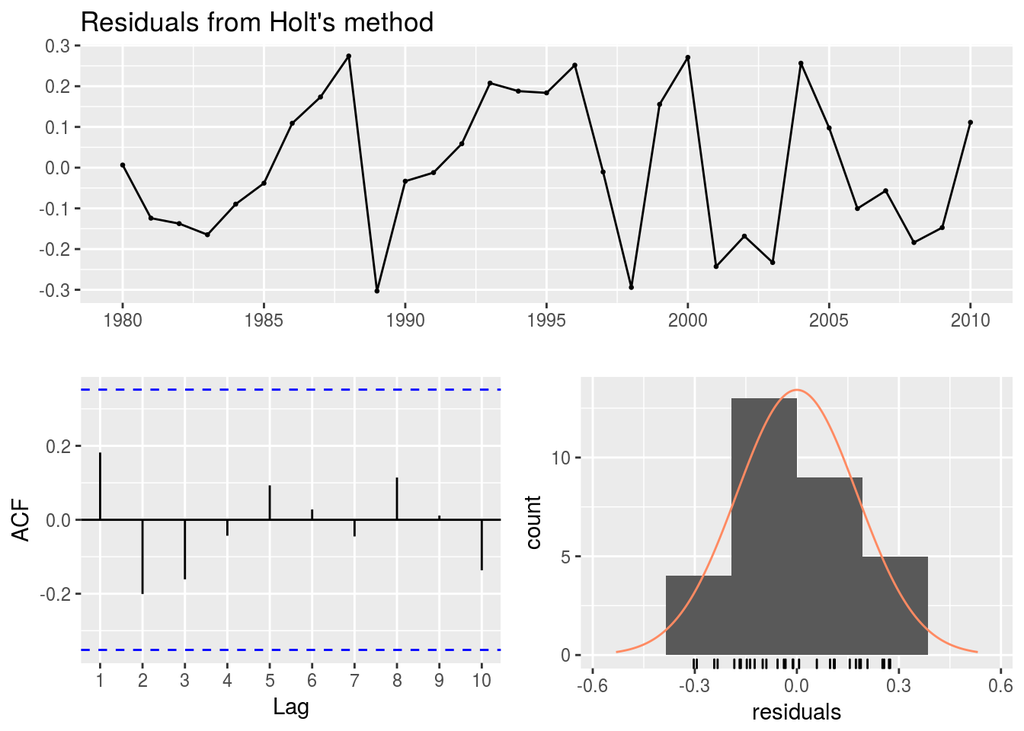

```
##
##  Ljung-Box test
##
## data:  residuals
## Q* = 5.5236, df = 6, p-value = 0.4786
##
## Model df: 4.   Total lags used: 10
```

```r
checkresiduals(fc)
```

## Exponential Smoothing methods with trenad and seasonality

### Holt - Winters

Holt - Winters works when there is both **trend** and **seasonality** 2 versions, additive and multiplicative.

The multaplicative method should be used if the seasonal variation increases with the level of the data. This case it doesn’t reall matter though.

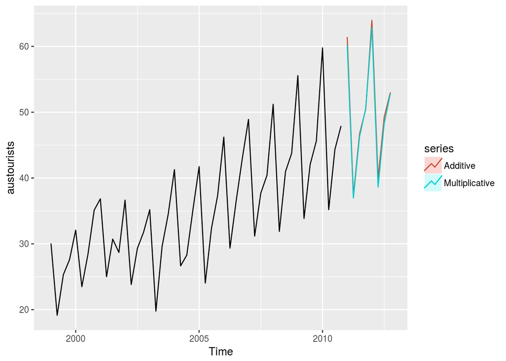

```r
window(austourists, start=2005) -> aust

hw(aust, seasonal="additive") -> fc1
hw(aust, seasonal="multiplicative") -> fc2

autoplot(austourists) +
  autolayer(fc1, PI=FALSE, series="Additive") +
  autolayer(fc2, PI=FALSE, series="Multiplicative")
```

## Taxonomy of exponential smoothing methods

|  | Seasonal Component |  |  |
| --- | --- | --- | --- |
| Trend Component | N (None) | A (Additive) | M (Multiplicative) |
| N (None) | (N, N) | (N, A) | (N, M) |
| A (Additive) | (A, N) | (A, A) | (A, M) |
| Ad (Additive Damped) | (Ad, N) | (Ad, N) | (Ad, N) |

[output not shown]

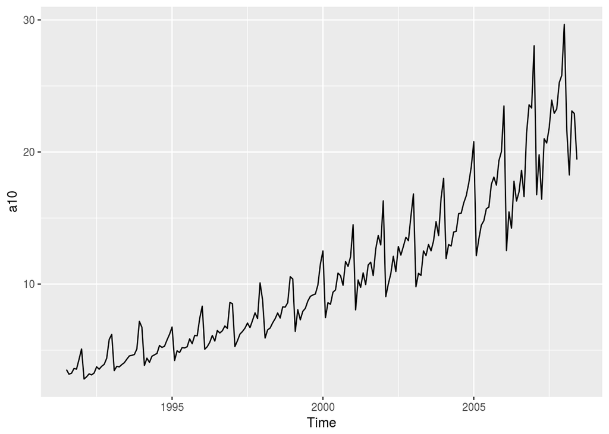

```r
# Plot the data
autoplot(a10)
```

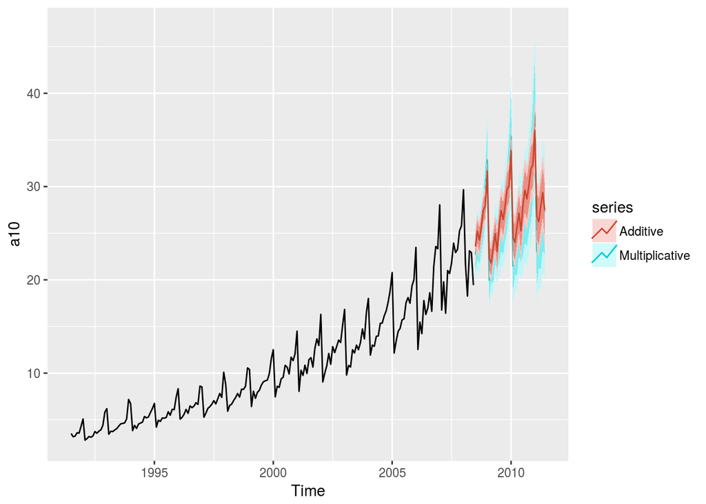

```r
# Produce 3 year forecasts
fc1 <- hw(a10, h=36, seasonal='multiplicative')
fc2 <- hw(a10, h=36, seasonal='additive')

# Plot forecasts
autoplot(a10) +
  autolayer(fc1, series='Multiplicative') +
  autolayer(fc2, series='Additive')
```

## Innovations state space models

- Each exponential smoothing method can be written as an **“innovations state space model”**
- Trend = ${N, A, A_d}$
- Seasonal = ${N, A, M}$
- ERROR = ${A, M}$

*3 x 3 = 9 possible exponential smoothing methods*

## ETS models

**E**rror, **T**rend, **S**easonality models

- Parameters: estimated using the “likelihoo”, the probability of the data arising from the specified model
- For models with additive errors, this is **equivolent to minimizing SSE**
- Choose the best model by minimizing a corrected version of Akaike’s Information Criterion (AIC). Similar to cross validation but much faster.

The `ets()` function does this for you!

for ausair the best model is **ETS(M, A, N)**. This is a **M**ultiplicative errors, **A**dditive trend and **N**o seasonality.

A difference between `ets()` and `hw()` is that it doesn’t create the forecast, you need to take the output and put it into the `forecast()` function and plot that.

We see in the example below the linear prediction. And how the error grows over time from the multiplicative errors component.

```r
ets(ausair) -> fc
print(fc)
```

```
## ETS(M,A,N)
##
## Call:
##  ets(y = ausair)
##
##   Smoothing parameters:
##     alpha = 0.9999
##     beta  = 1e-04
##
##   Initial states:
##     l = 6.5062
##     b = 0.7621
##
##   sigma:  0.0715
##
##      AIC     AICc      BIC
## 186.0340 187.7987 194.4784
```

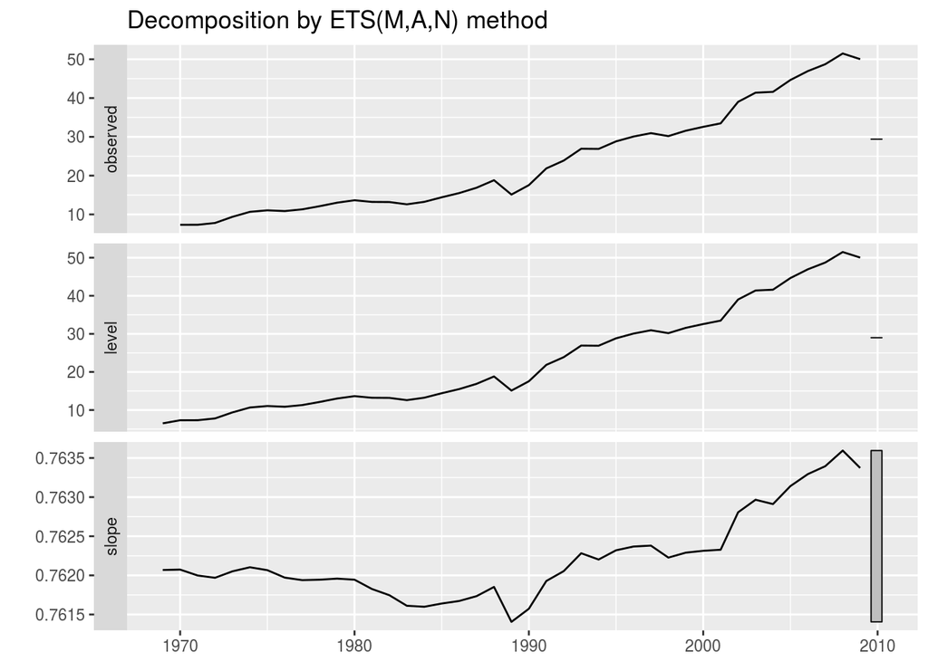

```r
autoplot(fc)
```

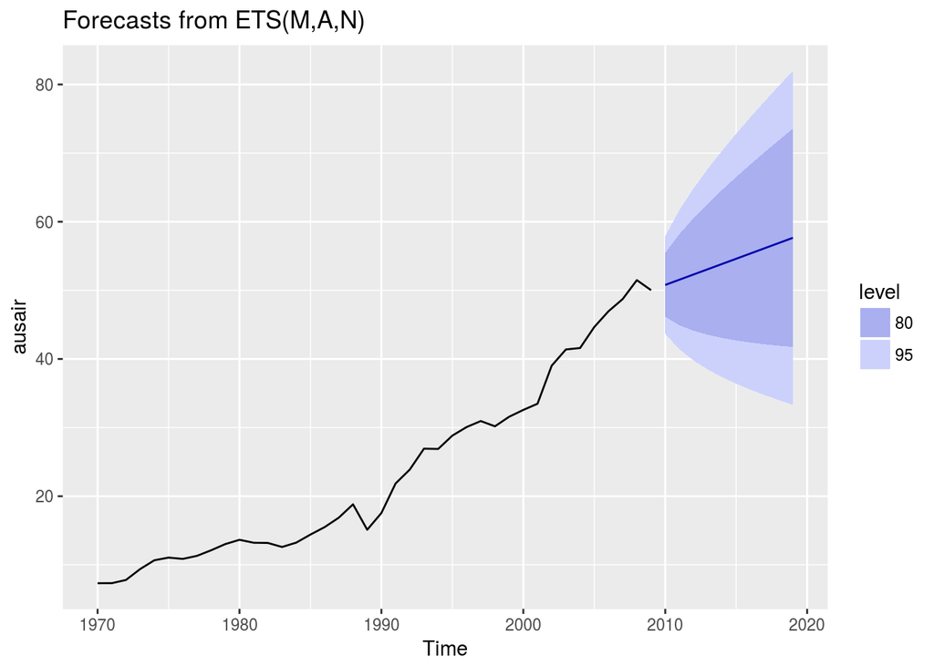

```r
fc %>% forecast() %>% autoplot()
```

A seasonal example

The model **ETS(M,Ad,M)** indicates **M**ultiplicative error, **A**dditive **d**ampening trend, **M**ultiplicative seasonality.

Note that because of the type of model there are many more parameters to estimate vs. the previous.

```r
ets(h02)
```

```
## ETS(M,Ad,M)
##
## Call:
##  ets(y = h02)
##
##   Smoothing parameters:
##     alpha = 0.2173
##     beta  = 2e-04
##     gamma = 1e-04
##     phi   = 0.9756
##
##   Initial states:
##     l = 0.3996
##     b = 0.0098
##     s=0.8675 0.8259 0.7591 0.7748 0.6945 1.2838
##            1.3366 1.1753 1.1545 1.0968 1.0482 0.983
##
##   sigma:  0.0647
##
##        AIC       AICc        BIC
## -123.21905 -119.52175  -63.49289
```

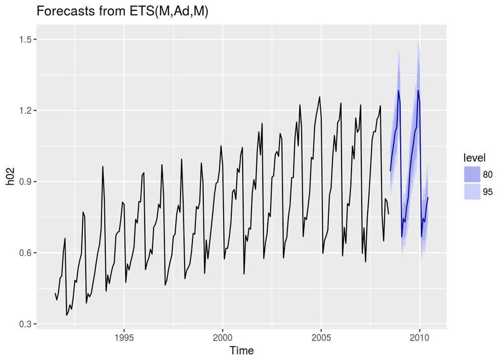

```r
ets(h02) %>% forecast() %>% autoplot()
```

## When ETS goes bad (Fails)

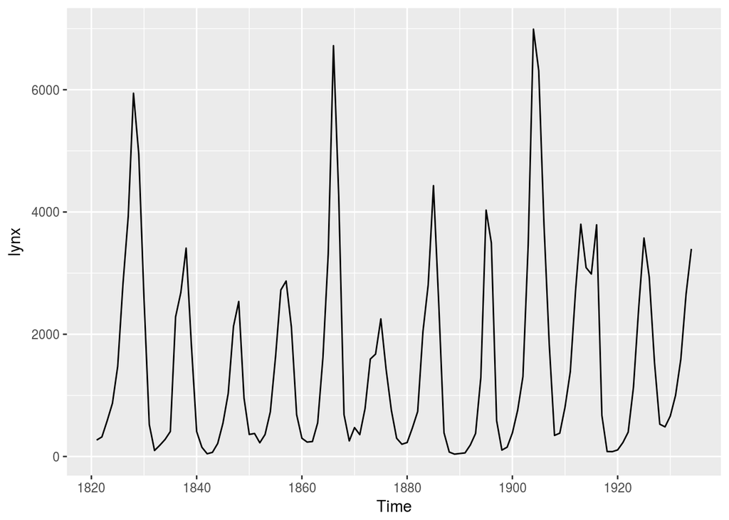

```r
autoplot(lynx)
```

```r
ets(lynx) -> fit

summary(fit)
```

```
## ETS(M,N,N)
##
## Call:
##  ets(y = lynx)
##
##   Smoothing parameters:
##     alpha = 0.9999
##
##   Initial states:
##     l = 169.2223
##
##   sigma:  0.9489
##
##      AIC     AICc      BIC
## 2052.369 2052.587 2060.578
##
## Training set error measures:
##                    ME     RMSE      MAE       MPE     MAPE      MASE
## Training set 28.30726 1182.181 824.4878 -44.94341 94.83425 0.9923325
##                   ACF1
## Training set 0.3785704
```

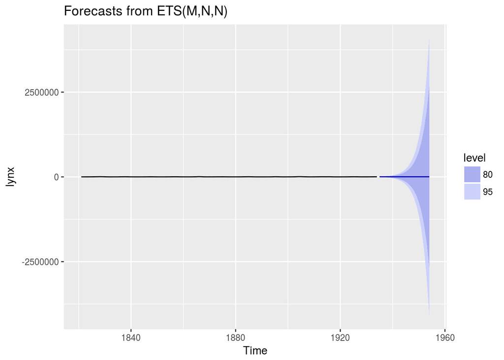

```r
fit %>% forecast(h=20) %>% autoplot()
```